# Exploration of Physical Activity Data by Nivedita Bijlani

# Multivariate Plots Section

We earlier looked at the relationship between bmi and gender and found that females are more likely than males to be obese. Let us investigate this relationship bringing age into the picture.

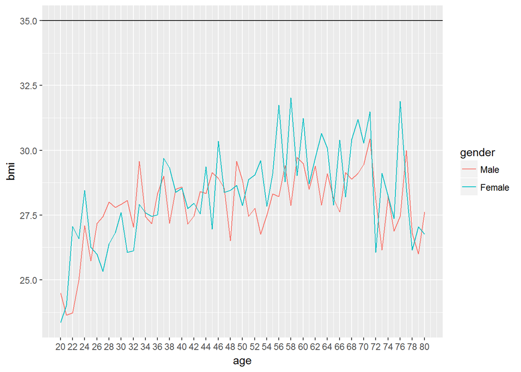

To compare this better, we zoom in on ages 20 to 50 and then ages 50 and 80:

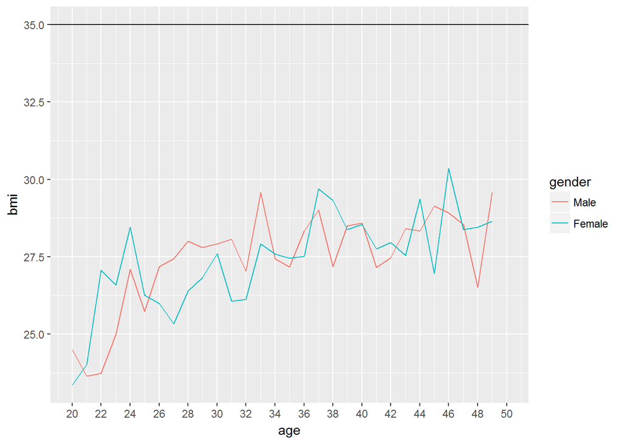

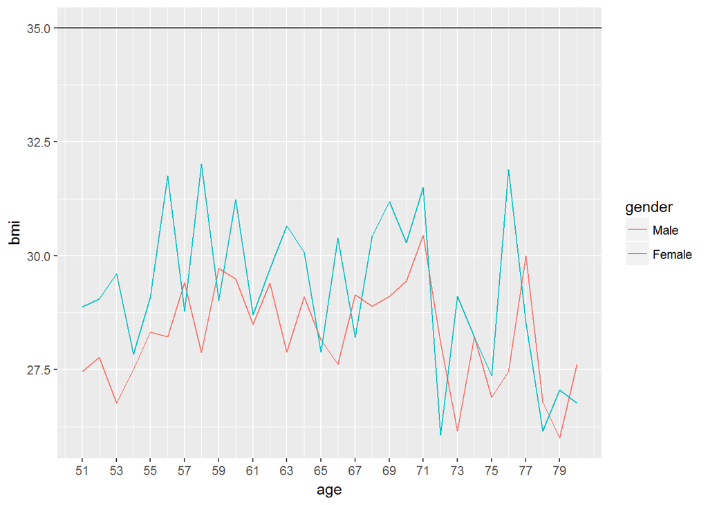

So how do work activity levels vary with age and gender?

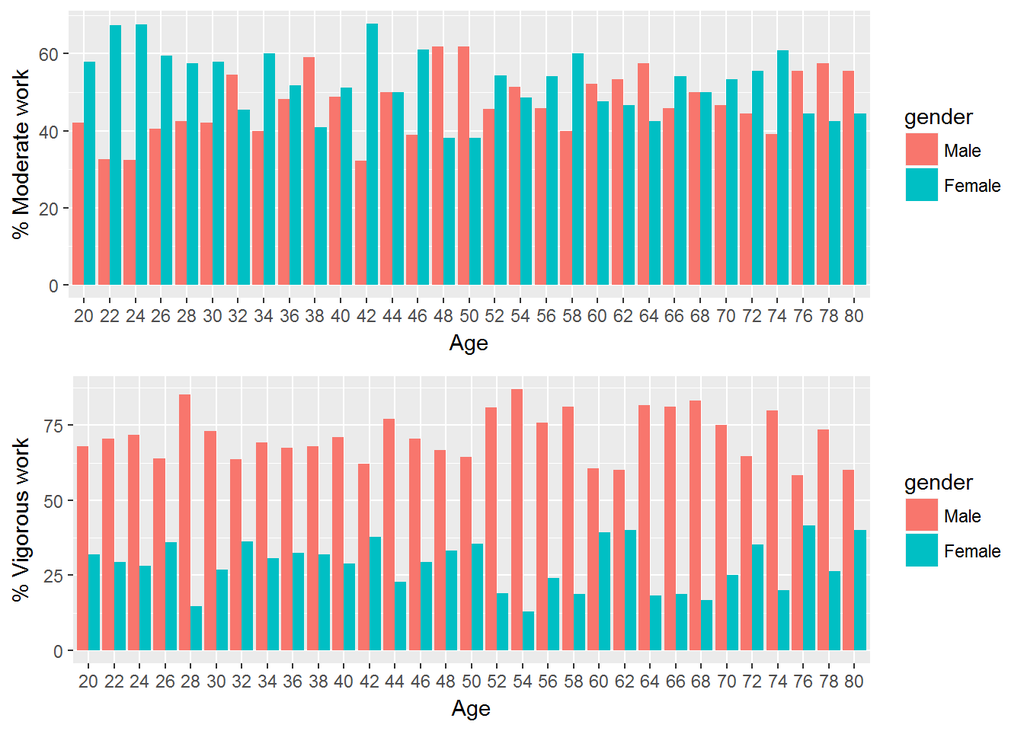

And how about recreational activity?

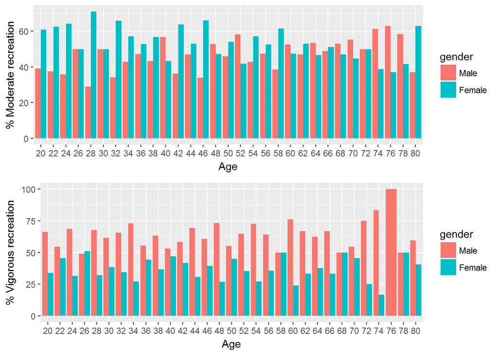

Let us investigate the variation in median bmi by age, gender, marital status:

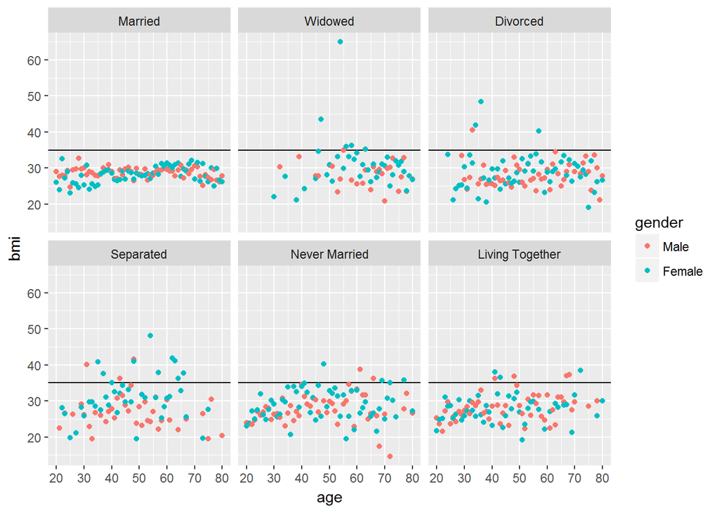

Inspecting the above graphs, we notice little variation in bmi by gender for married individuals. This points to the stability in general health for this group - both males and females. For widowed individuals, we see that females at ages 45 and 55 display widly high values of bmi. In fact, past the age of 45, widowed females hover around the obesity threshold mark of 35 and display on average, higher values of bmi than their male counterparts. This could be explained by not just the life-defining event of becoming widowed, but also by changes due to menopause coupled with responsibilities of a single career household and likely teenage children. Divorced individuals also show bmi variation by gender with females overtaking males on average bmi from the age of about 45. The figures for separated individuals show that bmi values for women at every age are slightly higher than males, with the widest variations seen from the age of 45. Figures for people who were never married show high variations in bmi with increase in age, again females with higher values on average. The pattern for people living together shows no clear pattern with age. Males and females show higher and lower bmi alternately. On the whole, this group is mostly comfortably below the bmi threshold with marginally higher values again around the 45 age mark.